# Extension: adverse-event costs and a three-drug frontier

Going beyond Cohen et al. (2023): SGLT2i safety costs and cost-effectiveness at 2026 prices

> *What this document is.* An extension of the validated reproduction adding what the published analysis omits: adverse-event costs, and empagliflozin, brand and generic dapagliflozin priced separately at 2026 FSS prices on a joint frontier. Model code is inherited unchanged; survival benefit is class-level, so the drugs compete on price.

# 1 Setup

Load packages and set the number of probabilistic sensitivity analysis (PSA) iterations. 1,000 probabilistic iterations were used.

```r
library("hesim")
library("data.table")
library("kableExtra")
library("flexsurv")
library("ggplot2")
library(flow) #Code Flow Diagrams
n_samples <- 1000

# Shared definitions.
source("R/helpers.R", local = knitr::knit_global())
source("R/model.R",   local = knitr::knit_global())
```

# 2 Model overview

*[Individual-level state-transition model](https://hesim-dev.github.io/hesim/articles/mstate.html)* of HFpEF in [`hesim`](https://hesim-dev.github.io/hesim/)<sup>1</sup> after Cohen et al.<sup>2</sup> “The paper” always means that single source, cited in full at the top of the reproduction document. Nine numbered transitions connect these states (see the transition matrix below). Living-state names in `hesim` are short labels. SGLT2i versus SoC, cohort matched to EMPEROR-Preserved<sup>3</sup> and DELIVER<sup>4</sup>.

# 3 Parameters

## 3.1 Transition structure

In an individual patient simulation, possible transitions are encoded in a matrix.

```r
tmat <- rbind(
  c(NA,  1,  NA,  2,  3),
  c(NA, NA,   4,  5,  6),
  c(NA,  7,  NA,  8,  9),
  c(NA, NA,  NA, NA, NA),
  c(NA, NA,  NA, NA, NA)
)
colnames(tmat) <- rownames(tmat) <- c("Stable", "HF Hospitalization",
                                       "Post-HF Hospitalization",
                                       "CV Death", "Non-CV Death")

# Display the matrix
tmat %>%
  kable(align = "c") %>%
  kable_styling()
```

|  | Stable | HF Hospitalization | Post-HF Hospitalization | CV Death | Non-CV Death |
| --- | --- | --- | --- | --- | --- |
| Stable | NA | 1 | NA | 2 | 3 |
| HF Hospitalization | NA | NA | 4 | 5 | 6 |
| Post-HF Hospitalization | NA | 7 | NA | 8 | 9 |
| CV Death | NA | NA | NA | NA | NA |
| Non-CV Death | NA | NA | NA | NA | NA |

Progression, CV death, non-CV death: *1-3* from Stable (first HF hospitalization), *4-6* from HF hospitalization, *7-9* from post-HF hospitalization; death states are all absorbing.

## 3.2 Strategies, patients, and hesim data objects

Three `hesim` building blocks: strategies, patients, three living cost/utility states; death in the transition matrix.

```r
strategies <- data.table(
  strategy_id = 1:2,
  strategy_name = c("SOC", "SGLT2i")
)
n_strategies <- nrow(strategies)

n_patients <- 3000
patients <- data.table(
  patient_id = 1:n_patients,
  gender = sample(c("Male", "Female"), n_patients, replace = TRUE, prob = c(0.557, 0.443)),
  age = pmin(round(rnorm(n_patients, mean = 71.7, sd = 9.5)), 115)  # cap < max_age (120)
)
```

Living states:

```r
states <- data.table(
  state_id   = 1:3,
  state_name = c("Stable", "HF Hospitalization", "Post-HF Hospitalization")
)
n_states <- nrow(states)   # = 3
```

Bundle strategies, patients, and states into a single `hesim_data` object:

```r
hesim_dat <- hesim_data(strategies = strategies,
                        patients = patients,
                        states = states)
print(hesim_dat)
```

```
## $strategies
##    strategy_id strategy_name
##          <int>        <char>
## 1:           1           SOC
## 2:           2        SGLT2i
##
## $patients
##       patient_id gender   age
##            <int> <char> <num>
##    1:          1   Male    78
##    2:          2   Male    63
##    3:          3   Male    66
##    4:          4   Male    69
##    5:          5 Female    77
##   ---
## 2996:       2996   Male    82
## 2997:       2997   Male    57
## 2998:       2998 Female    71
## 2999:       2999 Female    76
## 3000:       3000   Male    74
##
## $states
##    state_id              state_name
##       <int>                  <char>
## 1:        1                  Stable
## 2:        2      HF Hospitalization
## 3:        3 Post-HF Hospitalization
##
## attr(,"class")
## [1] "hesim_data"
```

`get_labels()` builds human-readable labels for tables and plots later in the document:

```r
hesim_labs <- get_labels(hesim_dat)
print(hesim_labs)
```

```
## $strategy_id
##    SOC SGLT2i
##      1      2
##
## $state_id
##                  Stable      HF Hospitalization Post-HF Hospitalization
##                       1                       2                       3
##                   Death
##                       4
```

## 3.3 Key literature inputs

Base-case model inputs; full Table 1 follows the utility and cost definitions. Rates are *per person-year* unless noted.

Key literature inputs for the multi-state model (base case). Source is the primary reference, else the paper’s Table 1.

| Parameter | Base case | Source |
| --- | --- | --- |
| First HF hospitalization rate | 0.0626 | Anker et al.<sup>3</sup>; Solomon et al.<sup>4</sup> |
| HF-hosp HR (SGLT2i vs SoC) | 0.74 | Vaduganathan et al.<sup>5</sup> |
| CV-death rate (in-trial) | 0.0356 | Anker et al.<sup>3</sup>; Solomon et al.<sup>4</sup> |
| CV-death HR | 0.88 | Vaduganathan et al.<sup>5</sup> |
| All-cause death rate (in-trial) | 0.0716 | Anker et al.<sup>3</sup>; Solomon et al.<sup>4</sup> |
| Non-CV death RR (in-trial) | 1.05 | Cohen et al.<sup>2</sup> |
| 30-day any-cause readmission | 21.27% | Cheng et al.<sup>6</sup>; Arora et al.<sup>7</sup>; Goyal et al.<sup>8</sup> |
| Rehospitalization RR, 2–6 mo | 0.34 | Chamberlain et al.<sup>9</sup> |
| Rehospitalization RR, 7–12 mo | 0.21 | Chamberlain et al.<sup>9</sup> |
| Rehospitalization RR, 13–24 mo | 0.18 | Chamberlain et al.<sup>9</sup> |
| PSA iterations | 1,000 | – |

Trial enrollment (N = 12,251 pooled) informs population characteristics.<sup>3,4</sup>

## 3.4 Transition-specific parameters

Each transition gets base rates or fixed times and, where relevant, SGLT2i effects, re-collected later for the PSA.

### 3.4.1 Transition 1: Stable → HF hospitalization

First HF hospitalization rates (6.26 per 100 person-years) are pooled from EMPEROR-Preserved<sup>3</sup> and DELIVER<sup>4</sup>. SGLT2i hazard ratio (0.74) was implemented from the trial meta-analysis.<sup>5</sup> In the full PSA these are drawn lognormally from Table 1 ranges; placeholders below are the point estimates.

```r
rateFirstHFhosp <- 0.0626
hrHFhosp_sglt2i <- 0.74
```

### 3.4.2 Transition 2: Stable → CV death

In-trial CV death rate; lifetime SGLT2i HR 0.88.<sup>5</sup> Post-trial: age-scaled hazard.

```r
rateCVdeath <- 0.0356  # 3.56 per 100 person-years
hrCVdeath_sglt2i <- 0.88
```

### 3.4.3 Transition 3: Stable → non-CV death

Non-CV mortality: *all-cause minus CV* (eMethods 2); RR 1.05 in-trial.

```r
rateAllCauseDeath <- 0.0716  # 7.16 per 100 person-years
rateCVdeath <- 0.0356        # 3.56 per 100 person-years

rateNonCVdeath <- rateAllCauseDeath - rateCVdeath  # = 0.0360 per person-year, Refer to eMethods 2, Step 7
rrNonCVdeath_sglt2i_intrial <- 1.05
```

### 3.4.4 Transition 4: HF hospitalization → post-HF hospitalization (discharge)

Length of stay is fixed at *7 days* for every admission (no treatment effect on stay duration).

### 3.4.5 Transition 5: HF hospitalization → CV death

Age-stratified in Table 1: fatal HF hospitalization 3.30% (3.14-3.46) if <75 y, 5.10% (4.99-5.21) if >=75 y; both beta.

Probabilities convert to rates over the 7-day stay via `prob_to_rate()`.

In-hospital death is later replaced by the background CV hazard; transition 5 is passed `cv_pwexp` in `params_surv_list()`.

```r
probInHospCVdeath_under75_shape1 <- 3.3
probInHospCVdeath_under75_shape2 <- 96.7
probInHospCVdeath_over75_shape1 <- 5.1
probInHospCVdeath_over75_shape2 <- 94.9
```

### 3.4.6 Transition 6: HF hospitalization → non-CV death

Same structure as transition 5 for non-cardiovascular in-hospital death (shape parameters from Table 1).

```r
probInHospNonCVdeath_shape1 <- 3.37
probInHospNonCVdeath_shape2 <- 96.63
```

### 3.4.7 Transition 7: Post-HF hospitalization → HF rehospitalization

30-day readmission 21.27% any-cause,<sup>6–8</sup> 48.21% HF-related,<sup>10</sup> later RRs 0.34/0.21/0.18;<sup>9</sup> Table 1.

```r
prob30d_readmit <- 0.2127
propHF_readmit <- 0.4821
rr_rehosp_2to6mo <- 0.34
rr_rehosp_7to12mo <- 0.21
rr_rehosp_13to24mo <- 0.18
rehosp_times <- c(0, 30/365, 6/12, 12/12)   # 4 pwexp knots matching rr_rehosp segments
```

### 3.4.8 Transition 8: Post-HF hospitalization → CV death

Same in-trial CV death rate and SGLT2i HR as transition 2 (background mortality after discharge).

```r
rateCVdeath_postHF <- 0.0356
hrCVdeath_sglt2i <- 0.88
```

### 3.4.9 Transition 9: Post-HF hospitalization → non-CV death

Same non-CV rate and in-trial RR as transition 3.

```r
rateNonCVdeath_postHF <- 0.0360
rrNonCVdeath_sglt2i_intrial <- 1.05
```

## 3.5 Multi-state model assembly

### 3.5.1 Collect rates and PSA knobs

Bring transition-level scalars into one place for the multi-state survival models. *`n_samples = 1000`* is the PSA size used for all probabilistic results in Table 2 and more.

```r
# Rates
rateFirstHFhosp <- 0.0626
rateCVdeath <- 0.0356
rateNonCVdeath <- 0.0360
rateCVdeath_postHF <- 0.0356
rateNonCVdeath_postHF <- 0.0360

# Fixed time
ttrDischarge <- 7/365

# Beta shape parameters
probInHospCVdeath_shape1 <- 4.2
probInHospCVdeath_shape2 <- 95.8
probInHospNonCVdeath_shape1 <- 3.37
probInHospNonCVdeath_shape2 <- 96.63
prob30d_readmit_shape1 <- 21.27
prob30d_readmit_shape2 <- 78.73
propHF_readmit <- 0.4821

# Piecewise RRs and times
rr_rehosp <- c(1.00, 0.34, 0.21, 0.18)
rehosp_times <- c(0, 30/365, 6/12, 12/12)

# PSA iterations
n_samples <- 1000  # PSA iterations (paper: 1,000)
```

### 3.5.2 Helper functions

`prob_to_rate()` converts a probability to a constant rate; `vec_to_dt()` builds the one-column `cons` table `hesim` expects.

```r
# Probability over interval t -> equivalent constant rate.
prob_to_rate <- function(p, t = 1) {
  (-log(1 - p)) / t
}

# 95% range -> lognormal SD on the log scale.
sdlog <- function(low, high) (log(high) - log(low)) / (2 * qnorm(0.975))
```

```r
# Scalars recycle to global n_samples.
vec_to_dt <- function(v, n = NULL){
  if (length(v) == 1) v <- rep(v, n_samples)
  dt <- data.table(v)
  colnames(dt) <- "cons"
  return(dt)
}

# Matrix or data.table of piecewise log-rates -> list of one-column coef tables.
as_dt_list <- function(x){
  x <- as.data.table(as.matrix(x))   # handles matrix or data.table input
  lapply(x, vec_to_dt)
}
```

Both are read from `R/helpers.R`, sourced in Setup, so they cannot drift; full contents of both shared files below.

### 3.5.3 US life tables and CV fraction of deaths

Sex-blended life-table hazards<sup>11</sup> give slope $b$ (Equation 1); CDC WONDER<sup>12</sup> sets CV-split shape, not level (eMethods 2).

$$\begin{aligned}
\textbf{(1)}\quad m_x^{(g)} &= -\log\!\bigl(1 - q_x^{(g)}\bigr),
&& g \in \{\text{male},\, \text{female}\},\quad x = 60, \dots,
99 \\[4pt]
\textbf{(2)}\quad m_x &= 0.557\, m_x^{(\text{male})} + 0.443\,
m_x^{(\text{female})}
&& \\[4pt]
\textbf{(3)}\quad \log m_x &= a + b\,x + \varepsilon_x,
&& x \geq 72 \quad\Longrightarrow\quad \hat{b} = 0.110\
\text{y}^{-1}
\end{aligned}$$

*Equation 1. Life-table $q_x$ to the post-trial mortality slope* ($R^2 = 0.999$). Only $\hat{b}$ carries forward: slope, not level.

### 3.5.4 Piecewise mortality gradient (in-trial flat, then age-rising)

$$\begin{aligned}
g(a) &= \begin{cases}
1, & a \leq \text{trial end (2.3 y)}\\[2pt]
k_{\text{calib}}\, e^{\,b\,(a-\text{anchor})}, & a >
\text{trial end}
\end{cases}
&\qquad
s_{\text{cv}}(a) &=
\min\!\Bigl(\tfrac{4.73}{3.54}\,\text{cv\_frac}(a),\; 0.95\Bigr)\\[6pt]
g_{\text{cv}}(a) &=
g(a)\,\frac{\lambda_{\text{cv}}+\lambda_{\text{ncv}}}{\lambda_{\text{cv}}}\;s_{\text{cv}}(a)
&\qquad
g_{\text{ncv}}(a) &=
g(a)\,\frac{\lambda_{\text{cv}}+\lambda_{\text{ncv}}}{\lambda_{\text{ncv}}}\;\bigl(1-s_{\text{cv}}(a)\bigr)
\end{aligned}$$

*Equation 3. Post-trial gradient; `k_calib` tuned to 7.73 y.*<sup>11,12</sup> (eMethods 2)

```r
baseline_age <- 72     # cohort mean 71.7
trial_end    <- 2.3
anchor_age   <- 73
k_calib      <- 0.94

rate_cv_intrial    <- 0.0356
rate_noncv_intrial <- 0.0360
hr_cv            <- 0.88
rr_ncv_intrial   <- 1.05   # all-cause HR ≈ 0.97
rr_ncv_posttrial <- 1.00

seg_starts <- seq(trial_end, 32.3, by = 5)
seg_times  <- c(0, seg_starts)              # 0, 2.3, 7.3, ... 32.3
mid_age    <- baseline_age + seg_starts + 2.5
# Cause split (eMethods 2): s_cv = (RR_cv/RR_all)*cv_frac(age); total hazard unchanged
xwalk_cv <- 4.73 / 3.54                     # RR_cv / RR_all
lvl_cv   <- rate_cv_intrial
lvl_ncv  <- rate_noncv_intrial

gradients      <- mortality_gradients()     # R/model.R; build_sens() calls the same function
cv_gradient    <- gradients$cv
noncv_gradient <- gradients$ncv
n_seg          <- length(cv_gradient)
```

### 3.5.5 Sample transition coefficients for the PSA

`define_rng()` samples beta transition probabilities; treatment HRs are drawn lognormally.

```r
# PSA RNG: beta (in-hosp death, 30-d readmit), fixed rates, piecewise rehosp
transmod_coef_def <- define_rng({

  # In-hospital CV death probability → rate over LOS
  probInHospCVdeath <- beta_rng(shape1 = probInHospCVdeath_shape1,
                                 shape2 = probInHospCVdeath_shape2)
  rateInHospCVdeath <- prob_to_rate(probInHospCVdeath, t = ttrDischarge)

  # In-hospital non-CV death probability → rate over LOS
  probInHospNonCVdeath <- beta_rng(shape1 = probInHospNonCVdeath_shape1,
                                    shape2 = probInHospNonCVdeath_shape2)
  rateInHospNonCVdeath <- prob_to_rate(probInHospNonCVdeath, t = ttrDischarge)

  # 30-day any-cause readmission → HF-related rate
  prob30d_readmit <- beta_rng(shape1 = prob30d_readmit_shape1,
                               shape2 = prob30d_readmit_shape2)
  prob30d_HFreadmit <- prob30d_readmit * propHF_readmit
  rate30d_HFreadmit <- prob_to_rate(prob30d_HFreadmit, t = 30/365)

  # Placeholder rates (levels re-drawn or re-scaled later where needed)
  rate1 <- fixed(rateFirstHFhosp)       # Stable → HF hosp
  rate2 <- fixed(rateCVdeath)           # Stable → CV death
  rate3 <- fixed(rateNonCVdeath)        # Stable → non-CV death
  rate8 <- fixed(rateCVdeath_postHF)    # Post-HF → CV death
  rate9 <- fixed(rateNonCVdeath_postHF) # Post-HF → non-CV death

  # Rehospitalization: base 30-d HF rate × piecewise RRs
  rehosp <- cbind(rate30d_HFreadmit * rr_rehosp[1],
                  rate30d_HFreadmit * rr_rehosp[2],
                  rate30d_HFreadmit * rr_rehosp[3],
                  rate30d_HFreadmit * rr_rehosp[4])
  colnames(rehosp) <- paste0("time_", rehosp_times)
  # Coefficients on log scale (except fixed discharge time)
  list(
    log_rate1 = vec_to_dt(log(rate1)),   # 1 Stable → HF hosp
    log_rate2 = vec_to_dt(log(rate2)),   # 2 Stable → CV death
    log_rate3 = vec_to_dt(log(rate3)),   # 3 Stable → non-CV death
    ttr4 = vec_to_dt(ttrDischarge),      # 4 HF hosp → post-HF (fixed)
    log_rate5 = vec_to_dt(log(rateInHospCVdeath)),    # 5
    log_rate6 = vec_to_dt(log(rateInHospNonCVdeath)), # 6
    log_rehosp = log(rehosp),            # 7 Post-HF → HF hosp (pwexp)
    log_rate8 = vec_to_dt(log(rate8)),   # 8 Post-HF → CV death
    log_rate9 = vec_to_dt(log(rate9))    # 9 Post-HF → non-CV death
  )
}, n = n_samples)

transmod_coef <- eval_rng(transmod_coef_def)
```

Draw the first HF hospitalization rate, its treatment hazard ratio, and the CV-death hazard ratio lognormally. The rate replaces its placeholder; the hazard ratios enter as `sglt2i` columns on the transitions that apply them directly:

```r
# One draw per sample, reused wherever that HR applies
set.seed(101)

rate1_draws  <- rlnorm(n_samples, log(rateFirstHFhosp), sdlog(0.0589, 0.0671)) # 6.26 (5.89-6.71)
hr_hfhosp_dr <- rlnorm(n_samples, log(hrHFhosp_sglt2i), sdlog(0.67, 0.83))     # 0.74 (0.67-0.83)
hr_cv_dr     <- rlnorm(n_samples, log(hrCVdeath_sglt2i), sdlog(0.77, 1.00))    # 0.88 (0.77-1.00)

# SGLT2i log columns
transmod_coef$log_rate1[, cons   := log(rate1_draws)]
transmod_coef$log_rate1[, sglt2i := log(hr_hfhosp_dr)]   # HF-hosp HR (trans 1)
transmod_coef$log_rate5[, sglt2i := log(hr_cv_dr)]       # CV-death HR (trans 5)
transmod_coef$log_rate6[, sglt2i := log(rrNonCVdeath_sglt2i_intrial)]  # non-CV RR fixed (no range)
```

Summarize the coefficient list:

```r
summary(transmod_coef)
```

```
##                                  param        mean         sd        2.5%
##                                 <char>       <num>      <num>       <num>
##  1:                     log_rate1_cons -2.77214921 0.03189176 -2.83194443
##  2:                   log_rate1_sglt2i -0.30195255 0.05689339 -0.41681781
##  3:                     log_rate2_cons -3.33540964 0.00000000 -3.33540964
##  4:                     log_rate3_cons -3.32423634 0.00000000 -3.32423634
##  5:                          ttr4_cons  0.01917808 0.00000000  0.01917808
##  6:                     log_rate5_cons  0.66423028 0.52064656 -0.55454002
##  7:                   log_rate5_sglt2i -0.12288300 0.06480032 -0.24756038
##  8:                     log_rate6_cons  0.41442369 0.59622147 -0.85830035
##  9:                   log_rate6_sglt2i  0.04879016 0.00000000  0.04879016
## 10:                  log_rehosp_time_0  0.26400796 0.19895455 -0.13453970
## 11: log_rehosp_time_0.0821917808219178 -0.81480170 0.19895455 -1.21334936
## 12:                log_rehosp_time_0.5 -1.29663979 0.19895455 -1.69518745
## 13:                  log_rehosp_time_1 -1.45079047 0.19895455 -1.84933813
```

[output cut: 19 more lines]

Inspect a few sampled tables (fixed discharge time; transition-1 log-rates with `cons` and `sglt2i`):

```r
head(transmod_coef$ttr4)
```

```
##          cons
##         <num>
## 1: 0.01917808
## 2: 0.01917808
## 3: 0.01917808
## 4: 0.01917808
## 5: 0.01917808
## 6: 0.01917808
```

```r
head(transmod_coef$log_rate1)
```

```
##         cons     sglt2i
##        <num>      <num>
## 1: -2.781831 -0.2736152
## 2: -2.752620 -0.4156912
## 3: -2.793433 -0.3062668
## 4: -2.763862 -0.2456800
## 5: -2.760657 -0.3054428
## 6: -2.731954 -0.3150429
```

### 3.5.6 Survival distributions for all nine transitions

Transitions need a distribution, coefficients, and (pwexp only) knot times: nine `params_surv()` in a `params_surv_list()`.

The chunk below:

It builds *piecewise-exponential CV/non-CV death* models with post-trial gradients, gives transitions 1-9 [*exp / fixed / pwexp*](https://hesim-dev.github.io/hesim/reference/params_surv.html) forms, keeps *background* hazards in hospital, and applies the *HF-hosp HR to readmissions* and first hospitalizations.

```r
# as_dt_list() is defined in R/helpers.R.

set.seed(1)
cv_draws    <- rlnorm(n_samples, log(rate_cv_intrial),    0.046)   # in-trial LEVEL, PSA
noncv_draws <- rlnorm(n_samples, log(rate_noncv_intrial), 0.046)

# Base case: CV-death HR for life.
cv_pwexp    <- make_death_pwexp(cv_draws, cv_gradient, rep(list(log(hr_cv_dr)), n_seg))
noncv_pwexp <- make_death_pwexp(noncv_draws, noncv_gradient,
                  c(list(log(rr_ncv_intrial)),
                    rep(list(log(rr_ncv_posttrial)), n_seg - 1)))

transmod_params <- params_surv_list(
  params_surv(coefs = list(rate = transmod_coef$log_rate1), dist = "exp"),        # 1
  params_surv(coefs = cv_pwexp,    aux = list(time = seg_times), dist = "pwexp"), # 2
  params_surv(coefs = noncv_pwexp, aux = list(time = seg_times), dist = "pwexp"), # 3
  params_surv(coefs = list(est = transmod_coef$ttr4), dist = "fixed"),            # 4
  # Trans 5–6: background CV/non-CV hazard in HF-hosp (no double-counted in-hosp death)
  params_surv(coefs = cv_pwexp,    aux = list(time = seg_times), dist = "pwexp"), # 5
  params_surv(coefs = noncv_pwexp, aux = list(time = seg_times), dist = "pwexp"), # 6
  # Trans 7: same HF-hosp HR on readmissions as on first hosp (aligned with hr_hfhosp_dr)
  params_surv(coefs = lapply(as_dt_list(transmod_coef$log_rehosp),
                             function(seg) seg[, sglt2i := log(hr_hfhosp_dr)][]),
              aux = list(time = rehosp_times), dist = "pwexp"),                    # 7
  params_surv(coefs = cv_pwexp,    aux = list(time = seg_times), dist = "pwexp"), # 8
  params_surv(coefs = noncv_pwexp, aux = list(time = seg_times), dist = "pwexp")  # 9
)
```

Rehospitalization knot count should match the number of piecewise coefficient columns.

```r
length(rehosp_times)
```

```
## [1] 4
```

```r
ncol(transmod_coef$log_rehosp)
```

```
## [1] 4
```

```r
colnames(transmod_coef$log_rehosp)
```

```
## [1] "time_0"                  "time_0.0821917808219178"
## [3] "time_0.5"                "time_1"
```

## 3.6 Utility and costs

### 3.6.1 Health-related quality of life

Utilities follow eMethods 4 and Table 1: baseline 0.783, SGLT2i +0.0084.

```r
# Table 1 utility; SE from 95% range
se_baseline <- (0.7859 - 0.7802) / (2 * 1.96)   # ≈ 0.00145
utility_baseline    <- 0.783
sglt2i_utility_gain <- 0.0084

disutility_hosp <- 0.16
age_util_slope  <- 0.0007

u_base <- rbeta(n_samples,
                utility_baseline * (utility_baseline*(1-utility_baseline)/se_baseline^2 - 1),
                (1-utility_baseline) * (utility_baseline*(1-utility_baseline)/se_baseline^2 - 1))
u_gain <- rnorm(n_samples, 0.0084, (0.0128 - 0.0040)/(2*1.96))   # Table 1 range

# No urgent-care state (-0.054 gap).
u_years <- 0:40
utility_tbl <- stateval_tbl(
  CJ(sample = 1:n_samples, strategy_id = strategies$strategy_id,
     state_id = states$state_id, time_start = u_years)[
    , `:=`(
        ub   = u_base[sample],
        gain = fifelse(strategy_id == 2L, u_gain[sample], 0),
        adec = fifelse(time_start >= 1, age_util_slope * (time_start - 1 + 0.5), 0),
        hdec = fifelse(state_id == 2L & time_start >= 1, disutility_hosp, 0))][
    , value := ub - adec - hdec + gain][
    , .(sample, strategy_id, state_id, time_start, value)],
  dist = "custom"
)
```

### 3.6.2 Drug costs

*Validation anchor.* The pooled 2022 FSS Big-4 price of $4,506,<sup>13</sup> less 18.62% discontinuation, gives $3,667 net annual drug cost in Stable and Post-HF, SGLT2i arm only. 2026 prices are defined here for the Figure 4 headline.

*2026 prices.*<sup>14</sup> Big-4 ceiling, 10 mg monthly: empagliflozin $313.42; brand dapagliflozin $444.96; generic $241.54.

```r
sglt2i_annual_cost <- 4506       # 2022 pooled FSS (validation anchor)
discontinuation_rate <- 0.1862   # 2022 pooled discontinuation
sglt2i_adjusted_cost <- sglt2i_annual_cost * (1 - discontinuation_rate)  # = $3667

# 2026 FSS Big-4, 10 mg daily, 30-tab bottle x 12 (VA OPAL/NAC file, 2026-03-01; ref 6)
price_empa       <- 313.42 * 12   # $3,761  JARDIANCE, NDC 00597-0152-30
price_dapa_brand <- 444.96 * 12   # $5,340  FARXIGA,   NDC 00310-6210-30
price_dapa_gen   <- 241.54 * 12   # $2,898  dapagliflozin generic (Prasco), NDC 66993-0457-30

drugcost_tbl <- stateval_tbl(
  data.table(
    strategy_id = rep(strategies$strategy_id, each = n_states),
    state_id    = rep(states$state_id, times = n_strategies),
    est = c(
      0, 0, 0,                                      # SoC: no drug cost
      sglt2i_adjusted_cost, 0, sglt2i_adjusted_cost # SGLT2i: Stable + Post-HF
    )
  ),
  dist = "fixed"
)

head(drugcost_tbl)
```

```
##    strategy_id state_id      est
##          <int>    <int>    <num>
## 1:           1        1    0.000
## 2:           1        2    0.000
## 3:           1        3    0.000
## 4:           2        1 3666.983
## 5:           2        2    0.000
## 6:           2        3 3666.983
```

### 3.6.3 Medical costs

*Background medical costs* are annual rates by age band,<sup>15</sup> applied by length of stay; with mean start age about 72, bands switch at model years 0, 3, and 13. The model adds *$12,528 per admission* on *entry* to the HF-hospitalization state.<sup>16</sup>

```r
background_cost_bands <- data.table(
  time_start = c(0, 3, 13),
  mean = c(23004, 23871, 32998),
  se   = c((23789 - 22217) / (2 * 1.96),    # age <75
           (24454 - 23288) / (2 * 1.96),    # age 75-84
           (33765 - 32231) / (2 * 1.96))    # age >=85
)
background_cost_annual <- background_cost_bands$mean[1]
background_cost_se     <- background_cost_bands$se[1]

hf_hosp_cost <- 12528

medcost_tbl <- stateval_tbl(
  data.table(
    state_id   = rep(states$state_id, each = nrow(background_cost_bands)),
    time_start = rep(background_cost_bands$time_start, times = n_states),
    mean       = rep(background_cost_bands$mean, times = n_states),
    se         = rep(background_cost_bands$se,   times = n_states)
  ),
  dist = "gamma"
)

# Per admission; method = "starting" is set below (wlos would understate it ~50x)
hfhospcost_tbl <- stateval_tbl(
  data.table(
    state_id = states$state_id,
    est = c(0, hf_hosp_cost, 0)
  ),
  dist = "fixed"
)

head(medcost_tbl)
```

```
##    state_id time_id time_start time_stop  mean       se
##       <int>   <int>      <num>     <num> <num>    <num>
## 1:        1       1          0         3 23004 401.0204
## 2:        1       2          3        13 23871 297.4490
## 3:        1       3         13       Inf 32998 391.3265
## 4:        2       1          0         3 23004 401.0204
## 5:        2       2          3        13 23871 297.4490
## 6:        2       3         13       Inf 32998 391.3265
```

```r
head(hfhospcost_tbl)
```

```
##    state_id   est
##       <int> <num>
## 1:        1     0
## 2:        2 12528
## 3:        3     0
```

# 4 Table 1. Model inputs

This table mirrors the paper’s Table 1; “In model?” flags each input as implemented, approximated, or a structural gap.

Table 1. Model inputs (Cohen et al. 2023). ‘In model?’ flags implementation here; Source is the paper’s attribution.

[output not shown]

# 5 Simulation

## 5.1 Constructing the model

The economic model combines a multi-state *disease* model, a *utility* model, and *cost* models in one `IndivCtstm` object.

### 5.1.1 Disease model input data

`expand()` builds one row per treatment strategy × patient. That table is the input data for the continuous-time transition model.

```r
transmod_data <- expand(hesim_dat, by = c("strategies", "patients"))
head(transmod_data)
```

```
##    strategy_id patient_id strategy_name gender   age
##          <int>      <int>        <char> <char> <num>
## 1:           1          1           SOC   Male    78
## 2:           1          2           SOC   Male    63
## 3:           1          3           SOC   Male    66
## 4:           1          4           SOC   Male    69
## 5:           1          5           SOC Female    77
## 6:           1          6           SOC   Male    68
```

Covariate columns for the survival linear predictors: `sglt2i` carries the treatment effect, `cons` the intercept.

```r
transmod_data[, cons := 1]
transmod_data[, male := ifelse(gender == "Male", 1, 0)]
transmod_data[, sglt2i := ifelse(strategy_name == "SGLT2i", 1, 0)]
```

`clock = "forward"`: time from simulation start, not state entry; `start_age` sets the age cap.

```r
transmod <- create_IndivCtstmTrans(transmod_params,
                                   input_data = transmod_data,
                                   trans_mat = tmat,
                                   clock = "forward",
                                   start_age = patients$age)
```

### 5.1.2 Cost and utility models

Utility and cost `StateVals` objects are built from the tables defined earlier. Background medical cost uses the default length-of-stay weighting; HF hospitalization cost uses `method = "starting"` so the event cost fires once per admission.

```r
# Utility
utilitymod <- create_StateVals(utility_tbl,
                               n = n_samples,
                               hesim_data = hesim_dat)

# Costs
drugcostmod <- create_StateVals(drugcost_tbl,
                                n = n_samples,
                                hesim_data = hesim_dat)

medcostmod <- create_StateVals(medcost_tbl,
                               n = n_samples,
                               hesim_data = hesim_dat)

hfhospcostmod <- create_StateVals(hfhospcost_tbl,
                                  n = n_samples,
                                  hesim_data = hesim_dat,
                                  method = "starting")

costmods <- list(Drug = drugcostmod,
                 Medical = medcostmod,
                 HFhosp = hfhospcostmod)
```

### 5.1.3 Combining the models

Combine disease, utility, and cost models into a single economic model object:

```r
econmod <- IndivCtstm$new(trans_model = transmod,
                          utility_model = utilitymod,
                          cost_models = costmods)
```

## 5.2 Shared code

Both documents source the same two R utility files; the listings below are read from them and cannot drift.

### 5.2.1 `R/helpers.R`

Converts a published probability to a constant rate over its interval, and a 95% range to the PSA lognormal SD.

```r
# Probability over interval t -> equivalent constant rate.
prob_to_rate <- function(p, t = 1) {
  (-log(1 - p)) / t
}

# 95% range -> lognormal SD on the log scale.
sdlog <- function(low, high) (log(high) - log(low)) / (2 * qnorm(0.975))
```

`hesim` expects intercept-only survival coefficients as a one-column `cons` table; these build one from a scalar, a vector, or a matrix of piecewise log-rates.

```r
# Scalars recycle to global n_samples.
vec_to_dt <- function(v, n = NULL){
  if (length(v) == 1) v <- rep(v, n_samples)
  dt <- data.table(v)
  colnames(dt) <- "cons"
  return(dt)
}

# Matrix or data.table of piecewise log-rates -> list of one-column coef tables.
as_dt_list <- function(x){
  x <- as.data.table(as.matrix(x))   # handles matrix or data.table input
  lapply(x, vec_to_dt)
}
```

Builds the per-segment tables for a piecewise-exponential death transition: a log baseline rate scaled by the mortality gradient, plus the treatment log-HR.

```r
# Per-segment coef tables (cons + sglt2i log-HR) for a pwexp death model.
make_death_pwexp <- function(level, gradient, seg_loghr) {
  lapply(seq_along(gradient), function(i) {
    lh <- seg_loghr[[i]]
    data.table(cons   = log(level * gradient[i]),
               sglt2i = if (length(lh) == 1) rep(lh, length(level)) else lh)
  })
}
```

Both documents report probabilistic results as *mean (2.5th to 97.5th percentile)* across PSA samples, at two decimals, three decimals, or whole dollars.

```r
# Mean (2.5th to 97.5th pct) across PSA samples: 2 dp, 3 dp, money.
ui  <- function(x) sprintf("%.2f (%.2f to %.2f)", mean(x), quantile(x, .025), quantile(x, .975))
ui3 <- function(x) sprintf("%.3f (%.3f to %.3f)", mean(x), quantile(x, .025), quantile(x, .975))
uiM <- function(x) sprintf("%s (%s to %s)", format(round(mean(x)), big.mark = ","),
                           format(round(quantile(x, .025)), big.mark = ","),
                           format(round(quantile(x, .975)), big.mark = ","))
```

Fills eTables 7 and 11 with the ACC/AHA value colours the published eTable 7 uses; non-finite ICERs fall through to white rather than becoming `NA`.

```r
# ACC/AHA value bands, paper eTable 7.
value_bg <- function(x) {
  x   <- as.numeric(x)
  out <- rep("#FFFFFF", length(x))
  ok  <- is.finite(x)
  out[ok & x < 150000] <- "#FFF2CC"
  out[ok & x <  50000] <- "#D9EAD3"
  out
}
```

### 5.2.2 `R/model.R`

#### 5.2.2.1 `mortality_gradients()`

eMethods 2, computed in one place only: the PSA and every deterministic scenario call this function, so the two cannot drift apart.

```r
# eMethods 2. Single source of truth.
mortality_gradients <- function(kcal = k_calib) {
  grad_all <- kcal * exp(b * (mid_age - anchor_age))
  lvl_all  <- lvl_cv + lvl_ncv
  s_cv     <- pmin(xwalk_cv * cv_frac(mid_age), 0.95)
  list(cv  = c(1.0, grad_all * (lvl_all / lvl_cv)  * s_cv),
       ncv = c(1.0, grad_all * (lvl_all / lvl_ncv) * (1 - s_cv)))
}
```

#### 5.2.2.2 `build_sens()`

Rebuilds the model at mean parameter values with any input overridden through `ovr`. It opens by drawing the cohort and the `hesim` data container.

```r
build_sens <- function(ovr = list(), np = 6000, kcal = k_calib) {
  g <- function(nm, d) if (!is.null(ovr[[nm]])) ovr[[nm]] else d
  set.seed(42)
  abase <- g("base_age", 71.7)
  pats <- data.table(patient_id = 1:np,
    gender = sample(c("Male", "Female"), np, TRUE, c(0.557, 0.443)),
    age = pmin(round(rnorm(np, abase, 9.5)), 115))  # cap < max_age
  sts <- data.table(state_id = 1:3, state_name = states$state_name)
  hd  <- hesim_data(strategies = strategies, patients = pats, states = sts)
  vdt <- function(v) { v <- rep(v, 1); dt <- data.table(v); setnames(dt, "cons"); dt }
```

Segment grid and gradient come from the shared function above; then the rates and hazard ratios a scenario is allowed to override.

```r
  segT     <- seg_times
  grads    <- mortality_gradients(kcal)
  grad_cv  <- grads$cv
  grad_ncv <- grads$ncv
  nseg <- length(grad_cv)
  r1 <- g("rateFirstHFhosp", rateFirstHFhosp); hrHF <- g("hr_hfhosp", hrHFhosp_sglt2i); hrCV <- g("hr_cv", hrCVdeath_sglt2i)
  nrr  <- g("noncv_rr", rr_ncv_intrial)        # in-trial non-CV RR (1 = no mortality effect)
  npo  <- g("noncv_rr_post", rr_ncv_posttrial) # post-trial non-CV RR (1.05 = effect persists)
```

eTable 8’s waning scenarios ramp the treatment effect linearly to nothing over the five years after trial end; `wsegT` is each segment’s mean of that ramp.

```r
  te <- trial_end; wend <- te + 5                    # trial end; effect gone by 7.3 y
  wane <- isTRUE(g("hr_wane_5y", FALSE))             # HF-hosp + CV-death HRs
  qw   <- isTRUE(g("qol_wane_5y", FALSE))            # utility gain
  wsegT   <- c(1, 0.5, rep(0, nseg - 2))             # segment means of the linear ramp
  hrHFseg <- if (wane) log(hrHF) * wsegT else rep(log(hrHF), nseg)
  hrCVseg <- if (wane) log(hrCV) * wsegT else rep(log(hrCV), nseg)
```

In-hospital probabilities become rates over the interval they were measured on, at the beta means rather than PSA draws.

```r
  pCVd <- probInHospCVdeath_shape1 / 100
  pNCd <- probInHospNonCVdeath_shape1 / 100
  p30  <- prob30d_readmit_shape1 / 100
  rICV <- prob_to_rate(pCVd, ttrDischarge); rINC <- prob_to_rate(pNCd, ttrDischarge)
  r30  <- prob_to_rate(p30 * propHF_readmit, 30/365)
  rehosp <- log(outer(r30, rr_rehosp))
```

Log-rates and treatment log-HRs are packed into the coefficient tables `hesim` wants, one per transition.

```r
  cf <- list(
    r1 = vdt(log(r1)), ttr = vdt(ttrDischarge),
    r5 = vdt(log(rICV)), r6 = vdt(log(rINC)),
    reh = rehosp, r8 = vdt(log(rateCVdeath_postHF)), r9 = vdt(log(rateNonCVdeath_postHF)))
  cf$r1[, sglt2i := log(hrHF)]; cf$r5[, sglt2i := log(hrCV)]; cf$r6[, sglt2i := log(nrr)]
  mkpw <- function(lvl, gradv, loghr) lapply(seq_len(nseg), function(i)
            data.table(cons = log(lvl * gradv[i]), sglt2i = loghr[i]))
  cvpw  <- mkpw(rate_cv_intrial, grad_cv,  hrCVseg)   # hrCVseg == rep(log(hrCV),nseg) unless hr_wane_5y
  ncvpw <- mkpw(rate_noncv_intrial, grad_ncv, c(log(nrr), rep(log(npo), nseg - 1)))
  as_dt <- function(x){ x <- as.data.table(as.matrix(x)); lapply(x, vdt) }
```

Transition 1 is exponential with a constant hazard ratio, or piecewise-exponential when the effect wanes.

```r
  if (wane) {
    t1pw <- lapply(seq_len(nseg), function(i) data.table(cons = log(r1), sglt2i = hrHFseg[i]))
    ps1  <- params_surv(coefs = t1pw, aux = list(time = segT), dist = "pwexp")
  } else {
    ps1  <- params_surv(coefs = list(rate = cf$r1), dist = "exp")
  }
```

Transition 7 applies the HF-hospitalization hazard ratio to readmissions; waning adds trial-end and effect-end breakpoints to the rate grid.

```r
  if (wane) {
    reh_grid <- c(rehosp_times, te, wend)
    reh_lvl  <- r30 * c(rr_rehosp, rep(rr_rehosp[length(rr_rehosp)], 2))
    wseg_reh <- c(1, 1, 1, 1, 0.5, 0)
    reh7pw   <- lapply(seq_along(reh_lvl), function(i)
                  data.table(cons = log(reh_lvl[i]), sglt2i = log(hrHF) * wseg_reh[i]))
    ps7 <- params_surv(coefs = reh7pw, aux = list(time = reh_grid), dist = "pwexp")
  } else {
    ps7 <- params_surv(coefs = lapply(as_dt(cf$reh), function(seg) seg[, sglt2i := log(hrHF)][]),
                       aux = list(time = rehosp_times), dist = "pwexp")
  }
```

The nine transitions are collected into a `params_surv_list` and joined to the patient-by-strategy input data.

```r
  pr <- params_surv_list(
    ps1,
    params_surv(coefs = cvpw,  aux = list(time = segT), dist = "pwexp"),
    params_surv(coefs = ncvpw, aux = list(time = segT), dist = "pwexp"),
    params_surv(coefs = list(est = cf$ttr), dist = "fixed"),
    params_surv(coefs = cvpw,  aux = list(time = segT), dist = "pwexp"),  # HF-hosp death = background
    params_surv(coefs = ncvpw, aux = list(time = segT), dist = "pwexp"),
    ps7,
    params_surv(coefs = cvpw,  aux = list(time = segT), dist = "pwexp"),
    params_surv(coefs = ncvpw, aux = list(time = segT), dist = "pwexp"))
  td <- expand(hd, by = c("strategies", "patients"))
  td[, cons := 1]; td[, sglt2i := ifelse(strategy_name == "SGLT2i", 1, 0)]
  tr <- create_IndivCtstmTrans(pr, input_data = td, trans_mat = tmat,
                               clock = "forward", start_age = pats$age)
```

Baseline utility less the age and hospitalization decrements plus the treatment gain (eMethods 4); `qol_wane_5y` ramps the gain to zero.

```r
  ub <- g("utility_baseline", utility_baseline); ug <- g("u_gain", 0.0084)
  dh <- disutility_hosp; ads <- age_util_slope
  utbl <- stateval_tbl(                                # qol_wane_5y ramps `gain` to 0 over te..wend
    CJ(strategy_id = 1:2, state_id = 1:3, time_start = 0:40)[
      , gfrac := if (qw) pmax(0, pmin(1, (wend - time_start) / 5)) else 1][
      , `:=`(
          gain = fifelse(strategy_id == 2L, ug * gfrac, 0),
          adec = fifelse(time_start >= 1, ads * (time_start - 1 + 0.5), 0),
          hdec = fifelse(state_id == 2L & time_start >= 1, dh, 0))][
      , est := ub - adec - hdec + gain][
      , .(strategy_id, state_id, time_start, est)],
    dist = "fixed")
  um <- create_StateVals(utbl, n = 1, hesim_data = hd)
```

Three cost tables: the discontinuation-adjusted drug cost, background medical cost by age band, and the HF hospitalization cost.

```r
  adj <- g("drug_cost", sglt2i_annual_cost) * (1 - g("discont", discontinuation_rate))
  dct <- stateval_tbl(data.table(strategy_id = rep(1:2, each = 3), state_id = rep(1:3, 2),
    est = c(0,0,0, adj,0,adj)), dist = "fixed")
  bcbase <- g("background_cost", background_cost_bands$mean[1])                 # age <75 band (SA-overridable)
  bcv <- bcbase * background_cost_bands$mean / background_cost_bands$mean[1]    # age bands (Table 1 ratios)
  bct <- stateval_tbl(data.table(
    state_id   = rep(1:3, each = 3),                          # 1,1,1,2,2,2,3,3,3
    time_start = rep(c(0, 3, 13), times = 3),                 # ages <75,75-84,>=85 (mean start age 72)
    est        = rep(bcv, times = 3)), dist = "fixed")
  hct <- stateval_tbl(data.table(state_id = 1:3, est = c(0, g("hf_hosp_cost", hf_hosp_cost), 0)), dist = "fixed")
```

The cost tables become state-value models (the hospitalization cost charged on entry rather than accrued) and the three components form the model object.

```r
  cm <- list(Drug = create_StateVals(dct, n = 1, hesim_data = hd),
             Medical = create_StateVals(bct, n = 1, hesim_data = hd),
             HFhosp = create_StateVals(hct, n = 1, hesim_data = hd, method = "starting"))
  IndivCtstm$new(trans_model = tr, utility_model = um, cost_models = cm)
}
```

#### 5.2.2.3 `det_icer()` and `scen_metrics()`

A single simulation is too noisy to read an ICER from, so costs and QALYs are averaged over 40 fixed-seed replicates and the ratio taken of the means.

```r
det_icer <- function(ovr = list(), R = 40, np = 6000) {
  # Mean over R fixed-seed re-sims; ΔQALY is too noisy for a single run.
  e  <- build_sens(ovr, np = np)
  dq <- numeric(R); dc <- numeric(R)
  for (k in seq_len(R)) {
    set.seed(1000 + k)
    e$sim_disease(max_t = 60, max_age = 120); e$sim_qalys(dr = 0.03); e$sim_costs(dr = 0.03)
    cc <- e$summarize()
    q  <- cc$qalys[dr == 0.03, .(qalys = qalys), by = "strategy_id"]
    ct <- cc$costs[dr == 0.03 & category == "total", .(cost = costs), by = "strategy_id"]
    m  <- merge(q, ct, by = "strategy_id")
    dq[k] <- m$qalys[2] - m$qalys[1]; dc[k] <- m$cost[2] - m$cost[1]
  }
  mean(dc) / mean(dq)
}
```

`scen_metrics()` does the same but returns the full outcome set the supplement tables need, over R replicates at a given horizon and discount rate.

```r
scen_metrics <- function(ovr = list(), np = 4000, horizon = 60, disc = 0.03, R = 20) {
  e <- build_sens(ovr, np = np)
  runs <- vector("list", R); dq <- numeric(R); dc <- numeric(R)
  for (k in seq_len(R)) {
    set.seed(1000 + k)
    e$sim_disease(max_t = horizon, max_age = 120)
    e$sim_qalys(dr = disc); e$sim_costs(dr = disc)
    cc <- e$summarize(); dp <- e$disprog_
```

Per replicate: hospitalizations as entries into state 2, mean survival, and life-years accrued across the three living states.

```r
    hf  <- dp[to == 2, .N, by = "strategy_id"]
    hf  <- merge(data.table(strategy_id = 1:2), hf, by = "strategy_id", all.x = TRUE)
    hf[is.na(N), N := 0]
    surv <- dp[, .(s = max(time_stop)), by = c("strategy_id", "patient_id")][
              , .(surv = mean(s)), by = "strategy_id"]
    ly  <- dp[, {                                    # life-years in states 1-3
              w <- if (disc == 0) time_stop - time_start
                   else (exp(-disc * time_start) - exp(-disc * time_stop)) / disc
              .(ly = sum(ifelse(from <= 3, w, 0)) / np)
            }, by = "strategy_id"]
```

QALYs and costs come from `summarize()`; the six outcome tables are merged into one row per strategy.

```r
    q   <- cc$qalys[dr == disc, .(qalys = qalys), by = "strategy_id"]
    ct  <- cc$costs[dr == disc & category == "total", .(cost = costs), by = "strategy_id"]
    dg  <- cc$costs[dr == disc & category == "Drug",  .(drug = costs), by = "strategy_id"]
    m <- Reduce(function(a, b) merge(a, b, by = "strategy_id"),
                list(hf[, .(strategy_id, hf = N / np)], surv, ly, q, ct, dg))
    setorder(m, strategy_id)
    runs[[k]] <- m
    dq[k] <- m$qalys[2] - m$qalys[1]; dc[k] <- m$cost[2] - m$cost[1]
  }
```

Replicates are averaged, and the ICER is the mean incremental cost over the mean incremental QALY, never the mean of the per-replicate ratios.

```r
  M <- rbindlist(runs)[, lapply(.SD, mean), by = "strategy_id"]
  setorder(M, strategy_id)
  list(soc = M[1], sg = M[2],
       d_cost = mean(dc), d_qaly = mean(dq),
       icer = mean(dc) / mean(dq), tbl = M)
}
```

# 6 Figure 4: Headline: three drugs as equals at 2026 FSS prices

*This is the headline analysis.* The pooled $4,506 assumption behind the 2022-price validation anchor is dropped; three drugs run as equals, each its own 1,000-sample PSA at 2026 FSS Big-4 prices:

- *Empagliflozin*: EMPEROR-Preserved efficacy, JARDIANCE (brand-only).
- *Dapagliflozin (brand)*: DELIVER efficacy, FARXIGA.
- *Dapagliflozin (generic)*: DELIVER efficacy, Prasco.

Arms differ in HF-hosp HR (also readmissions), discontinuation, and 2026 price; seeds paired with the base case.

*Common standard-of-care baseline.* Pooled `rateFirstHFhosp` = 0.0626/y, not each trial’s placebo rate.

## 6.1 Adverse-event costs

Cohen omitted adverse events their impact inventory scoped (eTable 3).

Adverse events enter as expected annual costs, *without adding health states*.

Four modelling choices:

Adverse events enter as costs only, so QALYs are unchanged. Standard of care accrues background rates; all three drugs share one class-wide rate set from the EMPEROR-Pooled genitourinary analysis.<sup>26</sup> Only the excess is scaled by exposure.

*Scope.* Adverse-event costs apply to this Figure 4 path only; the supplement and Table 2 stay adverse-event-free.

Adverse-event inputs, 2022 USD. Annual cost/person-year $36.53 (SoC), $51.41 (SGLT2i), excess $14.88.

| Event | Rate/y (SoC) | Rate/y (SGLT2i) | Excess/y | Unit cost | Incidence source | Unit-cost basis |
| --- | --- | --- | --- | --- | --- | --- |
| Genital mycotic infection (uncomplicated) | 0.00100 | 0.00600 | 0.00500 | $130 | EMPEROR-Pooled (Ferreira), Table 2: IR/100 py; sHR for the PSA | Assumption (outpatient visit + antifungal); 0% hospitalized |
| Cystitis / lower UTI (uncomplicated) | 0.04100 | 0.05100 | 0.01000 | $200 | EMPEROR-Pooled (Ferreira), Table 2: IR/100 py; sHR for the PSA | Assumption (outpatient visit + antibiotic); ~91% outpatient |
| Complicated cystitis / pyelonephritis / urosepsis | 0.00200 | 0.00300 | 0.00100 | $11,000 | EMPEROR-Pooled (Ferreira), Table 2: IR/100 py; sHR for the PSA | US inpatient, HCUP/Premier-style |
| Diabetic ketoacidosis | 0.00036 | 0.00044 | 0.00007 | $17,000 | EMPEROR-Preserved Table S6 + DELIVER Table 2, counts / exposure | US inpatient, HCUP/NIS |

*$14.88/person-year on drug*, mostly complicated genitourinary infection.

EMPEROR-Pooled includes EMPEROR-Reduced; rates likely *understate* HFpEF incidence. Non-US unit costs excluded.

Figure 4 table. Three drugs, 2026 FSS prices, common standard-of-care arm; 1000-sample PSA, 3,000 patients/sample, 3% discount.

| Drug | Annual FSS price | Trial | Incr. cost | Incr. QALYs | Incr. AE cost | ICER | Pref. @ $150k |
| --- | --- | --- | --- | --- | --- | --- | --- |
| Empagliflozin | $3,761 | EMPEROR-Preserved | 21,106 (12,011 to 29,299) | 0.188 (-0.048 to 0.392) | $87 | $112,274 | 71.1% |
| Dapagliflozin (brand) | $5,340 | DELIVER | 33,112 (24,908 to 41,869) | 0.185 (-0.029 to 0.400) | $96 | $179,171 | 35.0% |
| Dapagliflozin (generic) | $2,898 | DELIVER | 18,935 (11,127 to 27,056) | 0.185 (-0.029 to 0.400) | $96 | $102,457 | 74.7% |

Figure 4A ranks mean ICERs vs $50k and $150k/QALY; 4B is the cost-effectiveness plane, 4C the acceptability curves.

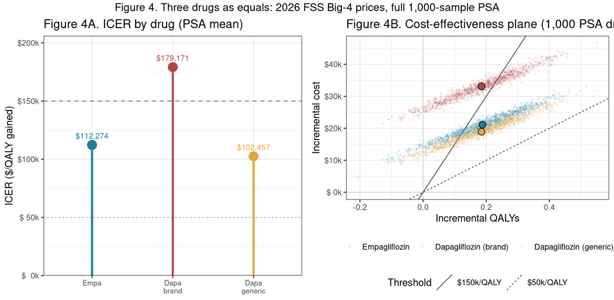

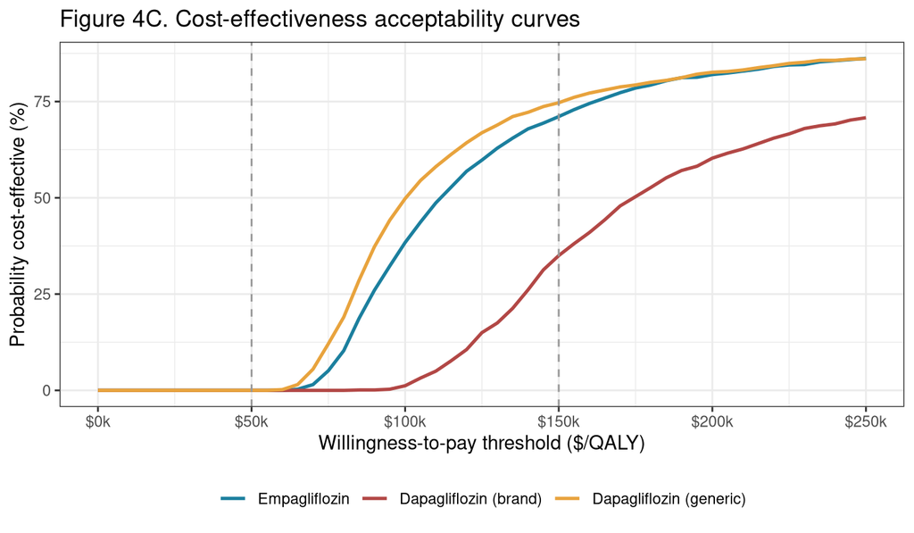

Distinct PSA clouds:<sup>27</sup> generic dapagliflozin costs least, empagliflozin’s HF-hosp HR is lowest.

## 6.2 Figure 4D: Cost-effectiveness acceptability frontier

Unlike *pairwise* Figure 4C, all four compete: faded curves are probabilities of highest net benefit; bold follows the *expected*-net-benefit maximiser.

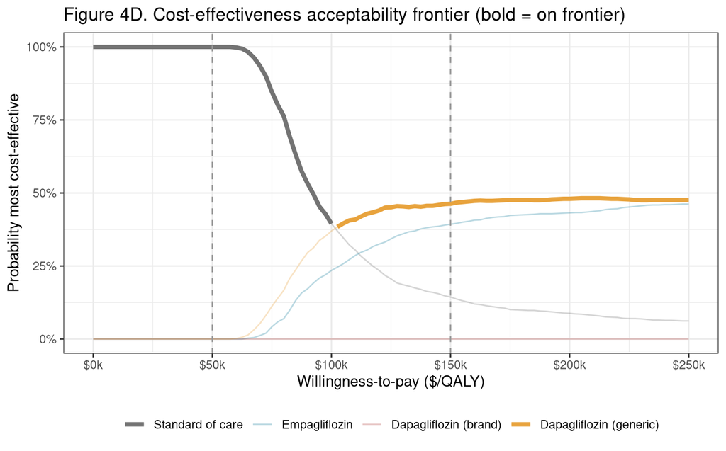

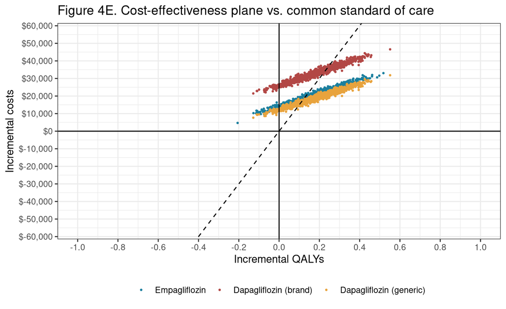

```
##              Outcome           Empagliflozin    Dapagliflozin (brand)
##               <fctr>                  <char>                   <char>
## 1: Incremental QALYs      0.19 (-0.05, 0.39)       0.18 (-0.03, 0.40)
## 2: Incremental costs 21,106 (12,011, 29,299)  33,112 (24,908, 41,869)
## 3:   Incremental NMB 7,092 (-20,296, 30,699) -5,391 (-29,713, 19,018)
## 4:              ICER                 112,274                  179,171
##    Dapagliflozin (generic)
##                     <char>
## 1:      0.18 (-0.03, 0.40)
## 2: 18,935 (11,127, 27,056)
## 3: 8,786 (-15,977, 33,775)
## 4:                 102,457
```

## 6.3 Figure 4F: Dominance and sequential ICERs

`hesim` omits dominance and extended dominance; computed below.

*Sequential ICER test.* Cost each strategy against the next cheapest; a fall means extended dominance.

```r
# hesim has no dominance/seq-ICER helper
frontier_tbl <- function(dt, tol = 1e-8) {
  ms <- dt[, .(e = mean(e), c = mean(c)), by = strategy][order(c, -e)]
  ms[, `:=`(Status = NA_character_, icer_seq = NA_real_)]

  # Dominance: weakly less effective than something already cheaper.
  keep <- integer(0); best_e <- -Inf
  for (i in seq_len(nrow(ms))) {
    if (ms$e[i] > best_e + tol) { keep <- c(keep, i); best_e <- ms$e[i] }
    else ms$Status[i] <- "dominated"
  }
  # extended dominance: above the skip chord
  repeat {
    if (length(keep) < 3L) break
    f  <- ms[keep]
    ic <- c(NA_real_, diff(f$c) / diff(f$e))     # ic[j] = ICER of f[j] vs f[j-1]
    j  <- which(diff(ic[-1]) < -tol)[1]
    if (is.na(j)) break
    ms$Status[keep[j + 1L]] <- "extendedly dominated"
    keep <- keep[-(j + 1L)]
  }
  ms$Status[keep] <- "on frontier"
  f <- ms[keep]
  if (nrow(f) > 1L) ms[keep[-1], icer_seq := diff(f$c) / diff(f$e)]
  ms[]
}

fr_ae   <- frontier_tbl(ceaDT)        # with adverse-event costs (headline)
fr_noae <- frontier_tbl(ceaDT_noae)   # price-only comparison

# Dominance turns on mean-QALY differences, so quantify how much of each is noise.
qref  <- "Dapagliflozin (generic)"
qbase <- ceaDT[strategy == qref][order(sample)]$e
qchk  <- rbindlist(lapply(setdiff(strat_lvls, qref), function(s) {
  d <- ceaDT[strategy == s][order(sample)]$e - qbase
  data.table(Strategy = s, dq = mean(d), se = sd(d) / sqrt(length(d)))
}))
qchk[, distinguishable := abs(dq) > 2 * se]
# Empagliflozin is the only comparison that is not an exact tie by construction.
empa_dq  <- qchk[Strategy == "Empagliflozin", dq]
empa_se  <- qchk[Strategy == "Empagliflozin", se]
empa_sig <- qchk[Strategy == "Empagliflozin", distinguishable]
```

Figure 4F. Joint frontier, 1000-sample PSA means; last column adverse-event-free.

| Strategy | Mean QALYs | Mean cost | Seq. ICER | Status | Price-only status |
| --- | --- | --- | --- | --- | --- |
| Standard of care | 5.154 | $167,377 | – | on frontier | on frontier |
| Dapagliflozin (generic) | 5.338 | $186,312 | $102,457 | on frontier | on frontier |
| Empagliflozin | 5.342 | $188,483 | $683,343 | on frontier | on frontier |
| Dapagliflozin (brand) | 5.338 | $200,490 | (dominated) | dominated | dominated |

Figure 4F effectiveness differences, paired by sample.

| Strategy | Δ mean QALYs vs generic dapagliflozin | Monte-Carlo SE | Distinguishable from zero? |
| --- | --- | --- | --- |
| Standard of care | -0.184809 | 0.003475 | yes |
| Empagliflozin | +0.003177 | 0.003486 | no (within 2 SE) |
| Dapagliflozin (brand) | +0.000000 | 0.000000 | no (within 2 SE) |

Adverse-event costs, exposure-scaled; last column reblends at $22.25 per on-drug person-year (1.49-fold).

| Drug | AE excess/on-drug py | Incr. AE cost (life) | % of incr. cost | ICER | ICER without AE | ICER, blended AE |
| --- | --- | --- | --- | --- | --- | --- |
| Empagliflozin | $11.43 | $87 | 0.41% | $112,274 | $111,812 | $112,502 |
| Dapagliflozin (brand) | $12.77 | $96 | 0.29% | $179,171 | $178,651 | $179,428 |
| Dapagliflozin (generic) | $12.77 | $96 | 0.51% | $102,457 | $101,937 | $102,714 |

*Standard-of-care baseline check.* The three standard-of-care arms differ only by Monte-Carlo noise (0.066% QALYs, 0.079% cost), and each drug is anchored to the common arm by its own paired increment, so that noise never reaches the frontier.

*Results.* Adverse events add $14.88 per on-drug person-year, 0.6% of generic dapagliflozin’s net annual drug cost: $87 to $96 discounted over a lifetime, moving ICERs by at most $520 per QALY. *Complicated cystitis / pyelonephritis / urosepsis* supplies 74%; diabetic ketoacidosis, the effect Cohen named, supplies 8.3%.

Adding adverse-event costs does not change which strategies are on the frontier, so closing Cohen’s limitation would not have altered their qualitative conclusion. Being *cost-only*, this bounds their economic impact, not their clinical importance.

Three cautions qualify Figure 4F.

*The drugs barely differ on effect.* QALYs come from the utility gain and the *shared* cardiovascular-death hazard ratio, not from the drug-specific HF-hospitalization HR, which only shifts time in a short non-fatal state. All three land within 0.0032 QALYs, so the frontier separates them on price.

*Empagliflozin’s position is not statistically resolved.* Its QALY difference from generic dapagliflozin, +0.003177, is smaller than its Monte-Carlo standard error of 0.003486. Read the classification as “no measurable QALY advantage at a materially higher price”.

*That classification is therefore not reproducible between runs.* The cohort is drawn *unseeded*, so each knit gets a different 3,000 patients and a difference this small can flip sign. A `set.seed()` would fix it but re-pin every published figure, so it is flagged rather than applied.

Two conclusions are *not* sensitive to this. Brand dapagliflozin ties the generic exactly at a higher price, so its dominance is arithmetic at any sample size; and a $14.88/person-year cost cannot move a frontier whose gaps run to thousands of dollars.

# 7 References

Except where noted, model inputs are those reported by Cohen et al.;<sup>2</sup> the citation given is the source *they* used, and the access dates are theirs.

1.

Incerti D, Jansen JP. hesim: Health Economic Simulation Modeling and Decision Analysis. *arXiv*. 2021;2102.09437. https://arxiv.org/abs/2102.09437

2.

Cohen LP, Isaza N, Hernandez I, et al. Cost-effectiveness of sodium-glucose cotransporter-2 inhibitors for the treatment of heart failure with preserved ejection fraction. *JAMA Cardiol*. 2023;8(5):419-428. doi:10.1001/jamacardio.2023.0077

3.

Anker SD, Butler J, Filippatos G, et al. Empagliflozin in heart failure with a preserved ejection fraction. *N Engl J Med*. 2021;385(16):1451-1461. doi:10.1056/NEJMoa2107038

4.

Solomon SD, McMurray JJV, Claggett B, et al. Dapagliflozin in heart failure with mildly reduced or preserved ejection fraction. *N Engl J Med*. 2022;387(12):1089-1098. doi:10.1056/NEJMoa2206286

5.

Vaduganathan M, Docherty KF, Claggett BL, et al. SGLT-2 inhibitors in patients with heart failure: A comprehensive meta-analysis of 5 randomized controlled trials. *Lancet*. 2022;400(10354):757-767. doi:10.1016/S0140-6736(22)01429-5

6.

Cheng RK, Cox M, Neely ML, et al. Outcomes in patients with heart failure with preserved, borderline, and reduced ejection fraction in the Medicare population. *Am Heart J*. 2014;168(5):721-730. doi:10.1016/j.ahj.2014.07.008

7.

Arora S, Lahewala S, Hassan Virk HU, et al. Etiologies, trends, and predictors of 30-day readmissions in patients with diastolic heart failure. *Am J Cardiol*. 2017;120(4):616-624. doi:10.1016/j.amjcard.2017.05.028

8.

Goyal P, Loop M, Chen L, et al. Causes and temporal patterns of 30-day readmission among older adults hospitalized with heart failure with preserved or reduced ejection fraction. *J Am Heart Assoc*. 2018;7(9):e007785. doi:10.1161/JAHA.117.007785

9.

Chamberlain AM, Dunlay SM, Gerber Y, et al. Burden and timing of hospitalizations in heart failure: A community study. *Mayo Clin Proc*. 2017;92(2):184-192. doi:10.1016/j.mayocp.2016.11.009

10.

Shah KS, Xu H, Matsouaka RA, et al. Heart failure with preserved, borderline, and reduced ejection fraction: 5-year outcomes. *J Am Coll Cardiol*. 2017;70(20):2476-2486. doi:10.1016/j.jacc.2017.08.074

11.

Arias E, Xu J. US life tables, 2018. *Natl Vital Stat Rep*. 2020;69(12):1-45.

12.

US Centers for Disease Control and Prevention. CDC WONDER. 2021. Accessed September 18, 2021. https://wonder.cdc.gov

13.

US Department of Veterans Affairs. VA federal supply schedule service. 2022. Accessed January 28, 2022. https://www.fss.va.gov/

14.

US Department of Veterans Affairs, Office of Procurement, Acquisition and Logistics, National Acquisition Center. Pharmaceutical pricing data as of March 1, 2026: Federal Supply Schedule and National Contracts prices for all National Acquisition Center programs. 2026. Accessed July 29, 2026. https://department.va.gov/procurement-acquisition-and-logistics/wp-content/uploads/sites/56/2026/03/TPharmPrices2026-03-01.xlsx

15.

Isaza N, Calvachi P, Raber I, et al. Cost-effectiveness of dapagliflozin for the treatment of heart failure with reduced ejection fraction. *JAMA Netw Open*. 2021;4(7):e2114501. doi:10.1001/jamanetworkopen.2021.14501

16.

HCUPnet. Healthcare cost and utilization project (HCUP): Introduction to the HCUP Nationwide Inpatient Sample (NIS) 2018. 2020. Accessed September 10, 2021. https://www.hcup-us.ahrq.gov/db/nation/nis/NISIntroduction2018.pdf

17.

Packer M, Butler J, Zannad F, et al. Effect of empagliflozin on worsening heart failure events in patients with heart failure and preserved ejection fraction: EMPEROR-Preserved trial. *Circulation*. 2021;144(16):1284-1294. doi:10.1161/CIRCULATIONAHA.121.056824

18.

Goyal P, Almarzooq ZI, Horn EM, et al. Characteristics of hospitalizations for heart failure with preserved ejection fraction. *Am J Med*. 2016;129(6):635.e15-635.e26. doi:10.1016/j.amjmed.2016.02.007

19.

Bryant KB, Moran AE, Kazi DS, et al. Cost-effectiveness of hypertension treatment by pharmacists in Black barbershops. *Circulation*. 2021;143(24):2384-2394. doi:10.1161/CIRCULATIONAHA.120.051683

20.

Kazi DS, Bellows BK, Baron SJ, et al. Cost-effectiveness of tafamidis therapy for transthyretin amyloid cardiomyopathy. *Circulation*. 2020;141(15):1214-1224. doi:10.1161/CIRCULATIONAHA.119.045093

21.

Peterson C, Xu L, Florence C, Grosse SD, Annest JL. Professional fee ratios for US hospital discharge data. *Med Care*. 2015;53(10):840-849. doi:10.1097/MLR.0000000000000410

22.

Butler J, Filippatos G, Jamal Siddiqi T, et al. Empagliflozin, health status, and quality of life in patients with heart failure and preserved ejection fraction: The EMPEROR-Preserved trial. *Circulation*. 2022;145(3):184-193. doi:10.1161/CIRCULATIONAHA.121.057812

23.

Thomas M, Jones PG, Cohen DJ, et al. Predicting the EQ-5D utilities from the Kansas City Cardiomyopathy Questionnaire in patients with heart failure. *Eur Heart J Qual Care Clin Outcomes*. 2021;7(4):388-396. doi:10.1093/ehjqcco/qcab014

24.

Sullivan PW, Ghushchyan V. Preference-based EQ-5D index scores for chronic conditions in the US. *Med Decis Making*. 2006;26(4):410-420. doi:10.1177/0272989X06290495

25.

Jaagosild P, Dawson NV, Thomas C, et al. Outcomes of acute exacerbation of severe congestive heart failure: Quality of life, resource use, and survival. *Arch Intern Med*. 1998;158(10):1081-1089. doi:10.1001/archinte.158.10.1081

26.

Ferreira JP, Zannad F, Butler J, et al. Genitourinary tract infections and SGLT2 inhibitors in heart failure: An EMPEROR-Pooled analysis. *Eur J Heart Fail*. Published online 2026:xuag054. doi:10.1093/ejhf/xuag054

27.

Rane A, Nechi RN, Imam M, et al. Comparative value of dapagliflozin vs empagliflozin in patients with heart failure and preserved ejection fraction: A cost-effectiveness analysis. *J Manag Care Spec Pharm*. 2023;29(9):1045-1053. doi:10.18553/jmcp.2023.29.9.1045

28.

Sanders GD, Neumann PJ, Basu A, et al. Recommendations for conduct, methodological practices, and reporting of cost-effectiveness analyses: Second panel on cost-effectiveness in health and medicine. *JAMA*. 2016;316(10):1093-1103. doi:10.1001/jama.2016.12195